# Machine Learning Classification at Telemarketing

Daniel Lumban Gaol

5/3/2021

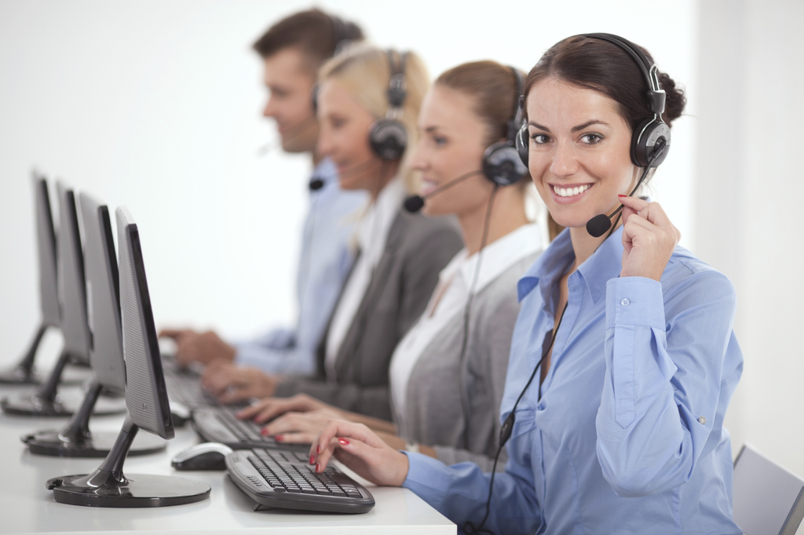

# 1 Case

At a bank in Portugal wants to predict what kind of prospective customer will buy a product from the bank when called by the bank, the purpose of this prediction is to help the telemarketing team to find out which customer will buy the product for yes or no based on campaign data. the marketing.

# 2 Library

```r
library(dplyr)
library(caret)
library(inspectdf)
library(gridExtra)
library(GGally)
library(rsample)
library(e1071)
library(ROCR)
```

# 3 Read Data

The data is related with direct marketing campaigns of a Portuguese banking institution. The marketing campaigns were based on phone calls. Often, more than one contact to the same client was required, in order to access if the product (bank term deposit) would be (‘yes’) or not (‘no’) subscribed.

```r
customer <- read.csv("bank-full.csv")
head(customer)
```

|  | age | job | marital | education | default | balance | housing | loan | contact | day | month | duration | campaign | pdays | previous | poutcome | y |
| --- | --- | --- | --- | --- | --- | --- | --- | --- | --- | --- | --- | --- | --- | --- | --- | --- | --- |
| 1 | 58 | management | married | tertiary | no | 2143 | yes | no | unknown | 5 | may | 261 | 1 | -1 | 0 | unknown | no |
| 2 | 44 | technician | single | secondary | no | 29 | yes | no | unknown | 5 | may | 151 | 1 | -1 | 0 | unknown | no |
| 3 | 33 | entrepreneur | married | secondary | no | 2 | yes | yes | unknown | 5 | may | 76 | 1 | -1 | 0 | unknown | no |
| 4 | 47 | blue-collar | married | unknown | no | 1506 | yes | no | unknown | 5 | may | 92 | 1 | -1 | 0 | unknown | no |
| 5 | 33 | unknown | single | unknown | no | 1 | no | no | unknown | 5 | may | 198 | 1 | -1 | 0 | unknown | no |
| 6 | 35 | management | married | tertiary | no | 231 | yes | no | unknown | 5 | may | 139 | 1 | -1 | 0 | unknown | no |

Column description :

age : Age

job : type of job

marital : marital status (category)

education : Categorical of education

default : has credit in default

balance : Saldo

housing : Categorical of has housing loan

loan : Personal loan

contact : contact communication type

day : last contact of day

month : last contact month of year

duration : last contact duration, in seconds (numeric)

campaign : number of contacts performed during this campaign and for this client

pdays : number of days that passed by after the client was last contacted from a previous campaign

previous : number of contacts performed before this campaign and for this client

poutcome : outcome of the previous marketing campaign

y : the client subscribed a term deposit

# 4 Data Wrangling

```r
glimpse(customer)
```

```
#> Rows: 45,211
#> Columns: 17
#> $ age       <int> 58, 44, 33, 47, 33, 35, 28, 42, 58, 43, 41, 29, 53, 58, 57, ~
#> $ job       <chr> "management", "technician", "entrepreneur", "blue-collar", "~
#> $ marital   <chr> "married", "single", "married", "married", "single", "marrie~
#> $ education <chr> "tertiary", "secondary", "secondary", "unknown", "unknown", ~
#> $ default   <chr> "no", "no", "no", "no", "no", "no", "no", "yes", "no", "no",~
#> $ balance   <int> 2143, 29, 2, 1506, 1, 231, 447, 2, 121, 593, 270, 390, 6, 71~
#> $ housing   <chr> "yes", "yes", "yes", "yes", "no", "yes", "yes", "yes", "yes"~
#> $ loan      <chr> "no", "no", "yes", "no", "no", "no", "yes", "no", "no", "no"~
#> $ contact   <chr> "unknown", "unknown", "unknown", "unknown", "unknown", "unkn~
#> $ day       <int> 5, 5, 5, 5, 5, 5, 5, 5, 5, 5, 5, 5, 5, 5, 5, 5, 5, 5, 5, 5, ~
#> $ month     <chr> "may", "may", "may", "may", "may", "may", "may", "may", "may~
#> $ duration  <int> 261, 151, 76, 92, 198, 139, 217, 380, 50, 55, 222, 137, 517,~
#> $ campaign  <int> 1, 1, 1, 1, 1, 1, 1, 1, 1, 1, 1, 1, 1, 1, 1, 1, 1, 1, 1, 1, ~
#> $ pdays     <int> -1, -1, -1, -1, -1, -1, -1, -1, -1, -1, -1, -1, -1, -1, -1, ~
#> $ previous  <int> 0, 0, 0, 0, 0, 0, 0, 0, 0, 0, 0, 0, 0, 0, 0, 0, 0, 0, 0, 0, ~
#> $ poutcome  <chr> "unknown", "unknown", "unknown", "unknown", "unknown", "unkn~
#> $ y         <chr> "no", "no", "no", "no", "no", "no", "no", "no", "no", "no", ~
```

```r
cust <- customer %>%
  mutate_if(is.character, as.factor)
```

inspect missing value

```r
colSums(is.na(cust))
```

```
#>       age       job   marital education   default   balance   housing      loan
#>         0         0         0         0         0         0         0         0
#>   contact       day     month  duration  campaign     pdays  previous  poutcome
#>         0         0         0         0         0         0         0         0
#>         y
#>         0
```

```r
cust_clean <- cust %>%
  select(-c("job","marital","education","contact","poutcome"))
```

On data that is binary option category, we will make it class 0 and 1,and we enter it into the processing data

```r
transform <- model.matrix(y ~ ., data = cust_clean) %>%
  as.data.frame() %>%
  select(c("defaultyes","housingyes","loanyes"))
```

```r
cust_clean$default <- transform$defaultyes
cust_clean$housing <- transform$housingyes
cust_clean$loan <- transform$loanyes
head(cust_clean)
```

|  | age | default | balance | housing | loan | day | month | duration | campaign | pdays | previous | y |
| --- | --- | --- | --- | --- | --- | --- | --- | --- | --- | --- | --- | --- |
| 1 | 58 | 0 | 2143 | 1 | 0 | 5 | may | 261 | 1 | -1 | 0 | no |
| 2 | 44 | 0 | 29 | 1 | 0 | 5 | may | 151 | 1 | -1 | 0 | no |
| 3 | 33 | 0 | 2 | 1 | 1 | 5 | may | 76 | 1 | -1 | 0 | no |
| 4 | 47 | 0 | 1506 | 1 | 0 | 5 | may | 92 | 1 | -1 | 0 | no |
| 5 | 33 | 0 | 1 | 0 | 0 | 5 | may | 198 | 1 | -1 | 0 | no |
| 6 | 35 | 0 | 231 | 1 | 0 | 5 | may | 139 | 1 | -1 | 0 | no |

# 5 Exploratory Data Analysis

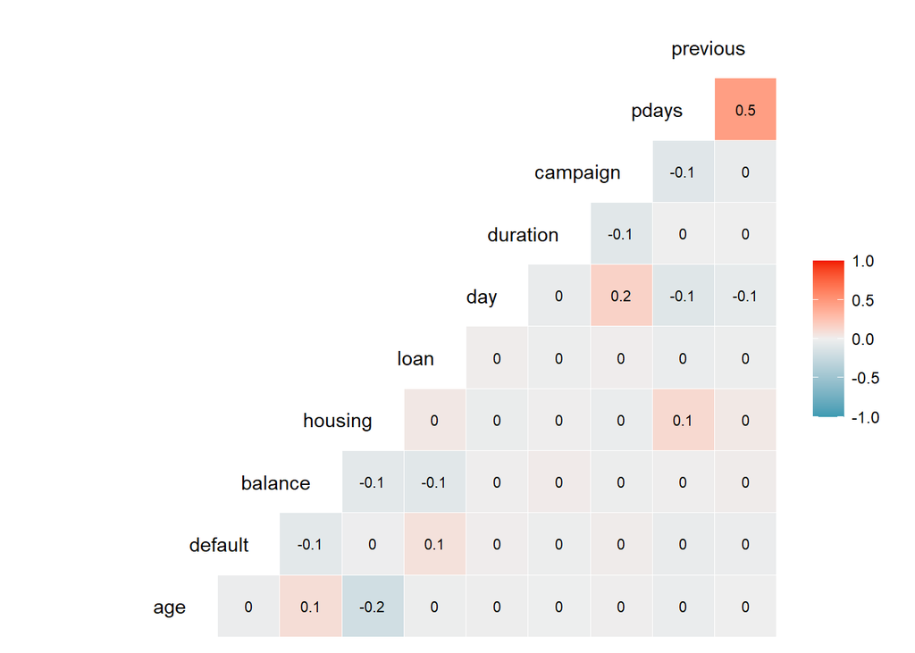

```r
ggcorr(cust_clean ,hjust = 1, layout.exp = 2, label = T, label_size = 2.9)
```

From the data above, all predictors that have a strong enough relationship are only `pdays` and`previous`, so it is still possible to use the Naive Bayes model.

```r
#Proportion of target variables before training data
prop.table(table(cust_clean$y))
```

```
#>
#>        no       yes
#> 0.8830152 0.1169848
```

> Cross Validation

```r
RNGkind(sample.kind = "Rounding")
set.seed(100)
index <- initial_split(data = cust_clean, prop = 0.8, strata ="y")

cust_train <- training(index)
cust_test <- testing(index)
```

Proporsi data

```r
#Proportion of target variables after training data
prop.table(table(cust_train$y))
```

```
#>
#>       no      yes
#> 0.882997 0.117003
```

After training data, the proportion of data still has the same proportion as the data before training, because the proportion of data is not balanced, we will use ‘downSample’ for data balancing

```r
set.seed(100)

down_cust <- downSample(x = cust_train %>% select(-y),
                     y = cust_train$y,
                     yname = "y")

prop.table(table(down_cust$y))
```

```
#>
#>  no yes
#> 0.5 0.5
```

# 6 Modeling

## 6.1 Naive Bayes

```r
cust_naive <- naiveBayes(x = down_cust %>% select(-y),
                         y = down_cust$y,
                         laplace = 1)
```

We can also interpret one of the predictors to find out the proportion of the class

```r
prop.table(table(down_cust$y, down_cust$month)) %>%
  as.data.frame() %>%
  rename(Class = Var1, Month = Var2)
```

| Class | Month | Freq |
| --- | --- | --- |
| no | apr | 0.030718336 |
| yes | apr | 0.053166352 |
| no | aug | 0.069116257 |
| yes | aug | 0.064981096 |
| no | dec | 0.001535917 |
| yes | dec | 0.008861059 |
| no | feb | 0.028119093 |
| yes | feb | 0.042060491 |
| no | jan | 0.015122873 |
| yes | jan | 0.013705104 |

[output cut: 14 more lines]

From the results above, it can be concluded that the class proportion of customers in the month `apr` for no = 3% and for yes = 5%

## 6.2 Naive Bayes Model Evaluation

```r
#model fitting
cust_pred <- predict(cust_naive, newdata = cust_test, type = "class")#for the class prediction
```

Evaluate the model with confusion matrix

```r
confusionMatrix(cust_pred, cust_test$y, positive = "yes")
```

```
#> Confusion Matrix and Statistics
#>
#>           Reference
#> Prediction   no  yes
#>        no  6054  224
#>        yes 1930  833
#>
#>                Accuracy : 0.7618
#>                  95% CI : (0.7528, 0.7705)
#>     No Information Rate : 0.8831
#>     P-Value [Acc > NIR] : 1
#>
#>                   Kappa : 0.3213
#>
#>  Mcnemar's Test P-Value : <0.0000000000000002
#>
#>             Sensitivity : 0.78808
#>             Specificity : 0.75827
#>          Pos Pred Value : 0.30148
#>          Neg Pred Value : 0.96432
#>              Prevalence : 0.11691
#>          Detection Rate : 0.09214
#>    Detection Prevalence : 0.30561
#>       Balanced Accuracy : 0.77317
#>
#>        'Positive' Class : yes
#>
```

From the evaluation results above, the Naive Bayes model gets 76% accuracy, 30% precision, recall, 78% in the positive class `Yes`

> ROC

Bentuk Probability dari hasil prediksi

```r
cust_prob <- predict(cust_naive, newdata = cust_test, type = "raw")#for the probability
round(head(cust_prob),4)
```

```
#>          no    yes
#> [1,] 1.0000 0.0000
#> [2,] 0.7801 0.2199
#> [3,] 0.7478 0.2522
#> [4,] 0.7830 0.2170
#> [5,] 0.7225 0.2775
#> [6,] 0.9871 0.0129
```

> Objek ROC

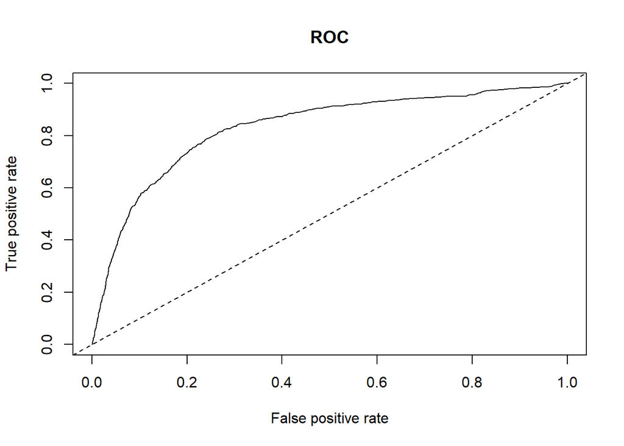

```r
#Objek Prediction
cust_roc <- prediction(predictions = cust_prob[,2], # = kelas positif
                       labels = as.numeric(cust_test$y == "yes")) # label kelas positif

#Objec performance dari prediction
perf <- performance(prediction.obj = cust_roc,
                    measure = "tpr",
                    x.measure = "fpr")
#plot
plot(perf, main = "ROC")
abline(0,1, lty =2)
```

## 6.3 Area Under Curve (AUC)

```r
auc <- performance(prediction.obj = cust_roc,
                   measure = "auc")
auc@y.values
```

```
#> [[1]]
#> [1] 0.8302735
```

The ROC is a probability curve representing the degree or measure of separation. This tells how much the model is able to differentiate between classes. The closer the curve reaches to the top left of the plot (true positive high and false positive low), the better our model will be. The higher the AUC score, the better the model will separate the target classes

# 7 Decision Tree

## 7.1 Model Fitting

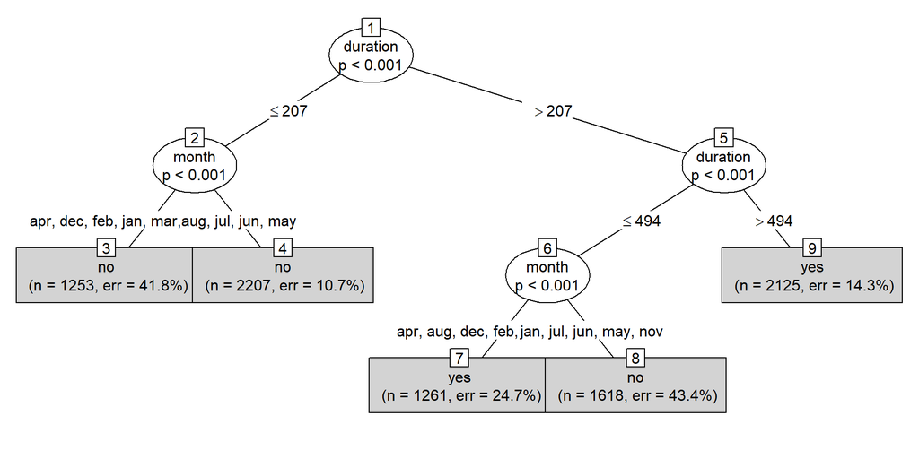

```r
library(partykit)
cust_tree <- ctree(formula = y ~ ., data = down_cust,
                   control = ctree_control(mincriterion = 0.5,
                                           minsplit = 500,
                                           minbucket = 1200))

plot(cust_tree, type = "simple")
```

From the plot decision tree above, it can be seen that 1 is the `Root Node`, 2,5 and 6 are the`Internal Node` and 3,4,7,8,9 are the`Leaf Nodes`

```r
predict.DT <- predict(cust_tree, newdata = cust_test)# For the class
predict.prob.DT <- predict(cust_tree, newdata = cust_test, type = "prob")# For the probability
```

```r
confusionMatrix(predict.DT, cust_test$y, positive = "yes")
```

```
#> Confusion Matrix and Statistics
#>
#>           Reference
#> Prediction   no  yes
#>        no  6692  338
#>        yes 1292  719
#>
#>                Accuracy : 0.8197
#>                  95% CI : (0.8116, 0.8276)
#>     No Information Rate : 0.8831
#>     P-Value [Acc > NIR] : 1
#>
#>                   Kappa : 0.3725
#>
#>  Mcnemar's Test P-Value : <0.0000000000000002
#>
#>             Sensitivity : 0.68023
#>             Specificity : 0.83818
#>          Pos Pred Value : 0.35753
#>          Neg Pred Value : 0.95192
#>              Prevalence : 0.11691
#>          Detection Rate : 0.07953
#>    Detection Prevalence : 0.22243
#>       Balanced Accuracy : 0.75920
#>
#>        'Positive' Class : yes
#>
```

From the results of the decision tree model confusion matrix, it can be seen that there is an increase in the accuracy value to 81%. Furthermore, the results of the confusion matrix will be evaluated using `ROC` and`AUC` to find out how well the model classifies the two classes.

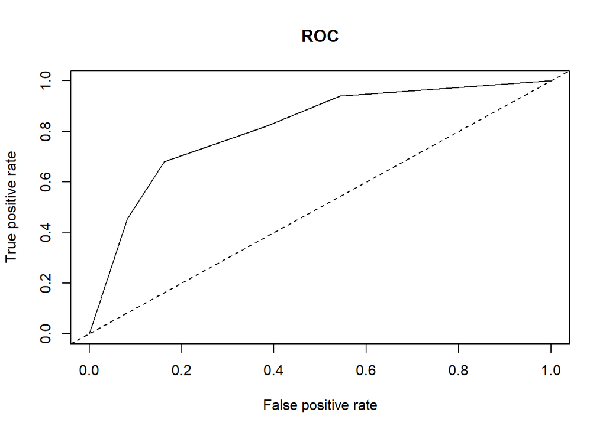

```r
#Objek Prediction
dt_roc <- prediction(predictions = predict.prob.DT[,2], # = kelas positif
                       labels = as.numeric(cust_test$y == "yes")) # label kelas positif

#Objec performance dari prediction
dt_perf <- performance(prediction.obj = dt_roc,
                    measure = "tpr",
                    x.measure = "fpr")
#plot
plot(dt_perf, main = "ROC")
abline(0,1, lty =2)
```

```r
dt_auc <- performance(prediction.obj = dt_roc,
                   measure = "auc")
dt_auc@y.values
```

```
#> [[1]]
#> [1] 0.8138376
```

# 8 Random Forest

One of the weaknesses of random forest is that the modeling takes a long time, so the model will be saved in the form of an RDS file with the function `saveRDS ()` so that the model can be used immediately without having to train before.

## 8.1 Data Prepocessing

```r
#discarding columns with low or close to 0 variance, so that they are not eligible to be used as predictors

n0_var <- nearZeroVar(down_cust)
down_cust <- down_cust[, -n0_var]
dim(down_cust)
```

```
#> [1] 8464   10
```

```r
#model building
# set.seed(2018)
# ctrl <- trainControl(method="repeatedcv", number=4, repeats=3) # k-fold cross validation
# forest <- train(y ~ ., data=down_cust, method="rf", trControl = ctrl)
# saveRDS(forest, "model.random.forest.rds")
```

```r
model_forest <- readRDS("model.random.forest.rds")
model_forest
```

```
#> Random Forest
#>
#> 8464 samples
#>    9 predictor
#>    2 classes: 'no', 'yes'
#>
#> No pre-processing
#> Resampling: Cross-Validated (4 fold, repeated 3 times)
#> Summary of sample sizes: 6348, 6348, 6348, 6348, 6348, 6348, ...
#> Resampling results across tuning parameters:
#>
#>   mtry  Accuracy   Kappa
#>    2    0.8390044  0.6780088
#>   10    0.8474716  0.6949433
#>   19    0.8438091  0.6876181
#>
#> Accuracy was used to select the optimal model using the largest value.
#> The final value used for the model was mtry = 10.
```

From the model summary,the optimum number of variables considered for splitting at each tree node `mtry` is 10 because the highest accuracy. We can also inspect the importance of each variable that was used in our random forest using varImp().

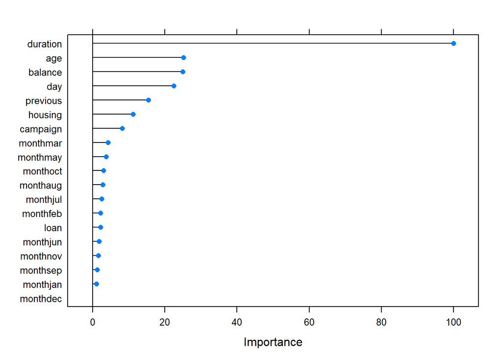

```r
Var_imp <- varImp(model_forest)
plot(Var_imp)
```

From the result, the importance variable can be interpreted into a plot, where the importance variable above is the `duration` variable.

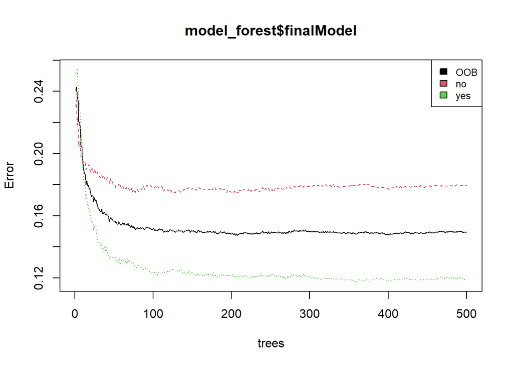

```r
plot(model_forest$finalModel)
legend("topright", colnames(model_forest$finalModel$err.rate),col=1:6,cex=0.8,fill=1:6)
```